# Illustrating logistic regression

Steve Simon

July 10, 2017

A simple data set that will help you understand logistic regression is the Titanic data set. It has information on the survival of 1,313 passengers on the cruise ship, Titanic, that was hit by an iceberg and sunk in the North Atlantic during its maiden voyage. The disaster occured during an era where people really did believe in “women and children, first” though this was more true for first class passengers.

I’m going to use a package from the tidyverse, readr, to get this data, though the regular read.table function included in R is more than up to the task of handling this small data set.

```r
library("readr")
library("magrittr")
f <- "http://www.statsci.org/data/general/titanic.txt"
ti <- read_tsv(f)
```

```
## `curl` package not installed, falling back to using `url()`
```

```r
names(ti) %<>% tolower
head(ti)
```

```
## # A tibble: 6 × 5
##                                            name pclass   age    sex
##                                           <chr>  <chr> <dbl>  <chr>
## 1                  Allen, Miss Elisabeth Walton    1st 29.00 female
## 2                   Allison, Miss Helen Loraine    1st  2.00 female
## 3           Allison, Mr Hudson Joshua Creighton    1st 30.00   male
## 4 Allison, Mrs Hudson JC (Bessie Waldo Daniels)    1st 25.00 female
## 5                 Allison, Master Hudson Trevor    1st  0.92   male
## 6                            Anderson, Mr Harry    1st 47.00   male
## # ... with 1 more variables: survived <int>
```

```r
tail(ti)
```

```
## # A tibble: 6 × 5
##                     name pclass   age    sex survived
##                    <chr>  <chr> <dbl>  <chr>    <int>
## 1    Zabour, Miss Tamini    3rd    NA female        0
## 2     Zakarian, Mr Artun    3rd    27   male        0
## 3 Zakarian, Mr Maprieder    3rd    26   male        0
## 4       Zenni, Mr Philip    3rd    22   male        0
## 5       Lievens, Mr Rene    3rd    24   male        0
## 6         Zimmerman, Leo    3rd    29   male        0
```

```r
ti$status <- ifelse(ti$survived==1, "lived", "died")
```

So the very first question you might ask is whether women fared better than men. Here is a simple table.

```r
tb <- table(ti$sex, ti$status)
print(tb)
```

```
##
##          died lived
##   female  154   308
##   male    709   142
```

This table tells you that 308 women survived, including Kate Winslet and that (spoiler alert!) 709 men died, including, sadly, Leonardo DiCaprio.

The raw counts are sometimes difficult to interpret, especially since there were a lot more men than women making the trip from England to America. You can get percentages with the prop.table function. The argument margin=1 gives row percentages.

```r
p <- prop.table(tb, margin=1)
p
```

```
##
##               died     lived
##   female 0.3333333 0.6666667
##   male   0.8331375 0.1668625
```

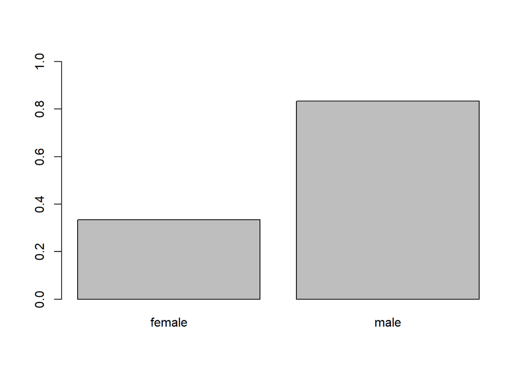

```r
barplot(height=p[ , "died"], names.arg=rownames(p), ylim=c(0, 1))
```

Looking at either the raw counts or the percentages, though, you can see that men in general fared worse than women. The ratio of deaths to survivals among men is 709 / 142 or 4.9929577 to 1 odds in favor of death. Let’s round this to 5 to 1 odds.

For women the ratio of survivals to deaths is 308 / 154 or exactly 2 to 1 odds against death. This is a ten fold change in odds. You have increase the 2 to 1 odds against death by a factor of 2 to get to even (1 to 1) odds and then by a factor of 5 to get to the male odds of death.

The ratio of odds is (not too surprisingly) called an odds ratio. The odds ratio is a commonly used measure in statistics, but it is not without a lot of controversy. But if you want to use a logistic regression model, you have to throw your lot in with the odds ratio. There are alternative regression approaches that use a different measure, such as the relative risk, but they are messier and used much less frequently.

There is no function in R that will compute an odds ratio for you, though you could do the calculation yourself. It is literally a ratio of odds.

```r
or <- (tb["female", "died"] / tb["female", "lived"]) /
      (tb[  "male", "died"] / tb[  "male", "lived"])
print(or)
```

```
## [1] 0.100141
```

Oops! I calculated an odds ratio of 10 earlier, but now it looks like the odds ratio is 0.1 instead. What happened? Well, the odds ratio depends on whether you put the odds associated with females in the numerator or the denominator and whether you use to the odds for death or the odds against death. You just have to get used to this, and start thinking that 1/10 and 10 are effectively the same odds ratio. Saying that men have 10 times the risk of dying than women is not any different than saying that women have 1/10 the risk of dying than men.

There are several packages that will calculate an odds ratio for you. One that I like is epitools.

```r
library(epitools)
oddsratio(ti$sex, ti$status)
```

```
## $data
##          Outcome
## Predictor died lived Total
##    female  154   308   462
##    male    709   142   851
##    Total   863   450  1313
##
## $measure
##          odds ratio with 95% C.I.
## Predictor  estimate      lower     upper
##    female 1.0000000         NA        NA
##    male   0.1004472 0.07686819 0.1305053
##
## $p.value
##          two-sided
## Predictor midp.exact fisher.exact   chi.square
##    female         NA           NA           NA
##    male            0 4.826448e-74 3.425855e-74
##
## $correction
## [1] FALSE
##
## attr(,"method")
## [1] "median-unbiased estimate & mid-p exact CI"
```

Notice that epitools, by default, selected the “wrong” odds ratio. This is because the default in R is to order the rows and columns of a table alphabetically, and that puts females in the first row and as a result their odds are in the numerator. The columns are also alphabetized, putting “died” before “lived” and thus calculating the odds against death. You can fix this easily with the rev=“columns” argument. Note that rev=“rows” would also flip the odds ratio.

```r
oddsratio(ti$sex,ti$status, rev="columns")
```

```
## $data
##          Outcome
## Predictor lived died Total
##    female   308  154   462
##    male     142  709   851
##    Total    450  863  1313
##
## $measure
##          odds ratio with 95% C.I.
## Predictor estimate    lower    upper
##    female 1.000000       NA       NA
##    male   9.956188 7.662525 13.00928
##
## $p.value
##          two-sided
## Predictor midp.exact fisher.exact   chi.square
##    female         NA           NA           NA
##    male            0 4.826448e-74 3.425855e-74
##
## $correction
## [1] FALSE
##
## attr(,"method")
## [1] "median-unbiased estimate & mid-p exact CI"
```

Logistic regression in R for a simple bivariate case like sex versus survival will produce the same odds ratios that we’ve seen earlier. You use the glm function in R (glm is short for general linear model, and logistic regression is a special case of the general linear model).

```r
ti$ideath <- as.numeric(ti$status=="died")
ti$imale <- as.numeric(ti$sex=="male")
msex <- glm(ideath~imale, family=binomial, data=ti)
summary(msex)
```

```
##
## Call:
## glm(formula = ideath ~ imale, family = binomial, data = ti)
##
## Deviance Residuals:
##     Min       1Q   Median       3Q      Max
## -1.8924  -0.9005   0.6042   0.6042   1.4823
##
## Coefficients:
##             Estimate Std. Error z value Pr(>|z|)
## (Intercept) -0.69315    0.09869  -7.023 2.17e-12 ***
## imale        2.30118    0.13488  17.061  < 2e-16 ***
## ---
## Signif. codes:  0 '***' 0.001 '**' 0.01 '*' 0.05 '.' 0.1 ' ' 1
##
## (Dispersion parameter for binomial family taken to be 1)
##
##     Null deviance: 1688.1  on 1312  degrees of freedom
## Residual deviance: 1355.5  on 1311  degrees of freedom
## AIC: 1359.5
##
## Number of Fisher Scoring iterations: 4
```

The odds ratio doesn’t look like an odds ratio. By default, R (like many other statistical pacakges) reports the log odds ratio. You can extract this log odds ratio and exponentiate it to get an odds ratio, but it takes a bit of work to figure out how to extract the log odds ratio.

```r
names(msex)
```

```
##  [1] "coefficients"      "residuals"         "fitted.values"
##  [4] "effects"           "R"                 "rank"
##  [7] "qr"                "family"            "linear.predictors"
## [10] "deviance"          "aic"               "null.deviance"
## [13] "iter"              "weights"           "prior.weights"
## [16] "df.residual"       "df.null"           "y"
## [19] "converged"         "boundary"          "model"
## [22] "call"              "formula"           "terms"
## [25] "data"              "offset"            "control"
## [28] "method"            "contrasts"         "xlevels"
```

```r
or <- round(exp(msex$coefficients["imale"]), 2)
print(or)
```

```
## imale
##  9.99
```

It gets worse when you need a standard error (e.g., for a confidence interval). You have to look not in the glm object but the summary of the glm object.

```r
ssex <- summary(msex)
names(ssex)
```

```
##  [1] "call"           "terms"          "family"         "deviance"
##  [5] "aic"            "contrasts"      "df.residual"    "null.deviance"
##  [9] "df.null"        "iter"           "deviance.resid" "coefficients"
## [13] "aliased"        "dispersion"     "df"             "cov.unscaled"
## [17] "cov.scaled"
```

```r
ssex$coefficients
```

```
##               Estimate Std. Error   z value     Pr(>|z|)
## (Intercept) -0.6931472 0.09869274 -7.023285 2.167120e-12
## imale        2.3011756 0.13488123 17.060755 2.907732e-65
```

```r
mn <- ssex$coefficients["imale", "Estimate"]
se <- ssex$coefficients["imale", "Std. Error"]
conf.limits <- round(exp(mn+c(-1.96,1.96)*se), 2)
print(conf.limits)
```

```
## [1]  7.67 13.01
```

You will find useful functions like coef() and predict() if you search through the help files, but in general, extracting information from a logistic regression model (or any regression model for that matter) is difficult.

There is a “tidyverse” package, broom, written by David Robinson, that makes extraction of these objects a bit easier. The nice thing about broom is that it provides a more or less uniform approach for extracting information that works across a wide variety of models.

The glance function in broom gives a one line summary of key statistics.

```r
library(broom)
glance(msex)
```

```
##   null.deviance df.null    logLik      AIC      BIC deviance df.residual
## 1      1688.065    1312 -677.7653 1359.531 1369.891 1355.531        1311
```

The tidy function gives a tabular summary that, for most statistical models, has one row for each independent variable (plus a row for the intercept, usually).

```r
tidy(msex)
```

```
##          term   estimate  std.error statistic      p.value
## 1 (Intercept) -0.6931472 0.09869274 -7.023285 2.167120e-12
## 2       imale  2.3011756 0.13488123 17.060755 2.907732e-65
```

The augment function adds predicted values and/or residuals to a data frame.

```r
n <- data.frame(imale=0:1)
augment(msex, newdata=n)
```

```
##   imale    .fitted    .se.fit
## 1     0 -0.6931472 0.09869274
## 2     1  1.6080285 0.09193852
```

The default predicted value is a log odds, and with a bit of work, you can convert this to a predicted probability. But life is too short for that. Tell broom to convert for you.

```r
augment(msex, newdata=n, type.predict="response")
```

```
##   imale   .fitted    .se.fit
## 1     0 0.3333333 0.02193172
## 2     1 0.8331375 0.01278124
```

Logistic regression with a continuous independent variable is not much more complicated, though the example you will see in just a minute has a few twists and turns.

Let’s plunge ahead and fit a model without looking at any graphs first. The first twist is that some of the ages are missing. The simplest thing to do, though it may not be the best choice, is to remove any row where age is missing.

```r
summary(ti$age)
```

```
##    Min. 1st Qu.  Median    Mean 3rd Qu.    Max.    NA's
##    0.17   21.00   28.00   30.40   39.00   71.00     557
```

```r
tj <- ti[is.finite(ti$age), ]
mage <- glm(ideath~age, family=binomial, data=tj)
tage <- tidy(mage)
tage$lcl <- exp(tage$estimate-1.96*tage$std.error)
tage$ucl <- exp(tage$estimate+1.96*tage$std.error)
tage$estimate <- exp(tage$estimate)
tage[ , c("term", "estimate", "lcl", "ucl")]
```

```
##          term estimate       lcl      ucl
## 1 (Intercept) 1.084835 0.7715598 1.525309
## 2         age 1.008833 0.9985418 1.019231
```

```r
or <- tage$estimate[tage$term=="age"]
n <- data.frame(age=1:71)
page <- augment(mage, newdata=n, type.predict="response")
print(page)
```

```
##    age   .fitted    .se.fit
## 1    1 0.5225403 0.04219956
## 2    2 0.5247341 0.04101270
## 3    3 0.5269268 0.03983369
## 4    4 0.5291186 0.03866340
## 5    5 0.5313092 0.03750280
## 6    6 0.5334986 0.03635295
## 7    7 0.5356868 0.03521500
## 8    8 0.5378735 0.03409025
## 9    9 0.5400588 0.03298010
## 10  10 0.5422426 0.03188613
## 11  11 0.5444247 0.03081009
## 12  12 0.5466051 0.02975392
## 13  13 0.5487838 0.02871976
## 14  14 0.5509606 0.02771004
```

[output cut: 57 more lines]

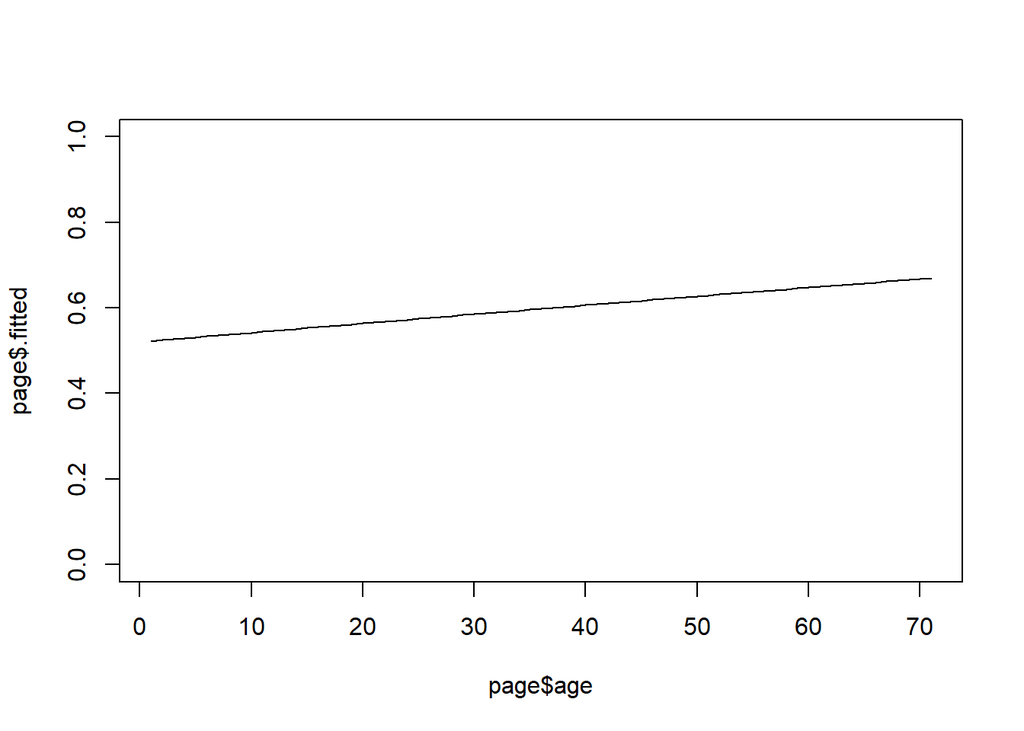

```r
plot(page$age, page$.fitted, type="l", ylim=c(0, 1))
```

There are so many different values for age, that it is easy to get confused. What is happening, though, is that each year of age causes a slight increase (1.009) in the odds of death. The change is easier to understand if you cumulate it across a decade of life. Each increase of ten years leads to a 1.009^10 or 1.092 increase in the odds of death.

There’s a big problem, though. Although there is a slight protective trend in survival in favor of children, the trend does not persist among adults. You can’t see it easily in a graph, but with a bit of work it becomes obvious. There are a couple of ways to look at this.

First, try a smooth fit to the raw data.

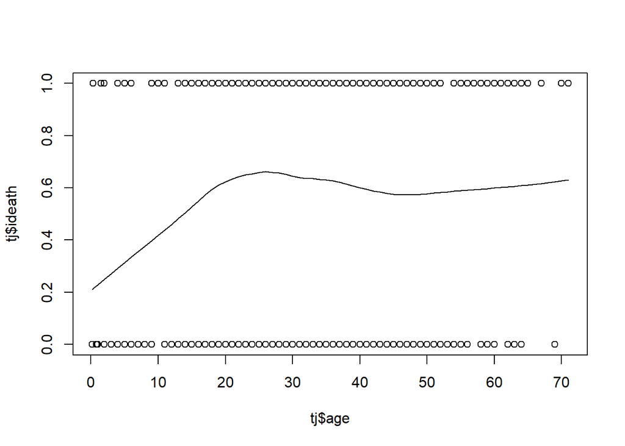

```r
plot(tj$age, tj$ideath)
lines(lowess(tj$age, tj$ideath))
```

Second, split the data into deciles (ten groups) and monitor the probability in each decile.

```r
library("dplyr")
age_group <- ntile(tj$age, 10)
range_label <- function(x) {
  paste(min(x), "to", max(x))
}
table(age_group)
```

```
## age_group
##  1  2  3  4  5  6  7  8  9 10
## 76 76 75 76 75 76 76 75 76 75
```

```r
decile_ages <- tapply(tj$age, age_group, mean)
decile_ranges <- tapply(tj$age, age_group, range_label)
decile_survival <- tapply(tj$survived, age_group, mean)
cbind(decile_ranges, decile_ages, decile_survival)
```

```
##    decile_ranges decile_ages        decile_survival
## 1  "0.17 to 16"  "6.93263157894737" "0.644736842105263"
## 2  "16 to 20"    "18.0263157894737" "0.447368421052632"
## 3  "20 to 22"    "21.0533333333333" "0.32"
## 4  "22 to 25"    "23.6052631578947" "0.368421052631579"
## 5  "25 to 28"    "26.64"            "0.346666666666667"
## 6  "28 to 32"    "29.9868421052632" "0.302631578947368"
## 7  "32 to 36"    "34.2105263157895" "0.5"
## 8  "36 to 43"    "39.4266666666667" "0.333333333333333"
## 9  "43 to 50"    "46.5526315789474" "0.434210526315789"
## 10 "50 to 71"    "57.8533333333333" "0.44"
```

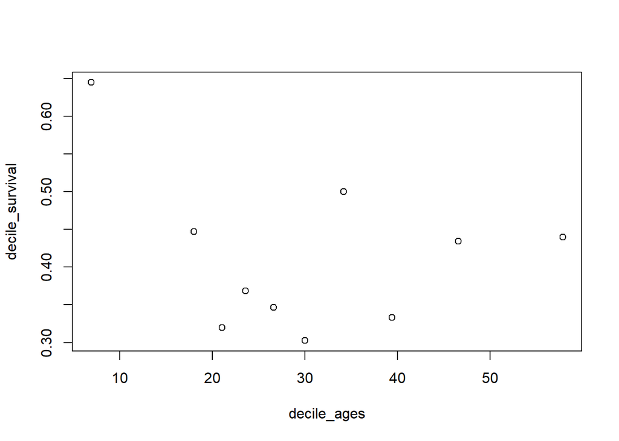

```r
plot(decile_ages, decile_survival)
```

You could also split the data into year intervals that are evenly spaced.

```r
library("dplyr")
age_group <- cut(tj$age, breaks=seq(0, 72, by=8))
range_label <- function(x) {
  paste(min(x), "to", max(x))
}
table(age_group)
```

```
## age_group
##   (0,8]  (8,16] (16,24] (24,32] (32,40] (40,48] (48,56] (56,64] (64,72]
##      46      37     205     180     114      83      51      32       8
```

```r
eight_year_ages <- tapply(tj$age, age_group, mean)
eight_year_ranges <- tapply(tj$age, age_group, range_label)
eight_year_survival <- tapply(tj$survived, age_group, mean)
cbind(eight_year_ranges, eight_year_ages, eight_year_survival)
```

```
##         eight_year_ranges eight_year_ages    eight_year_survival
## (0,8]   "0.17 to 8"       "3.38869565217391" "0.760869565217391"
## (8,16]  "9 to 16"         "13.0540540540541" "0.459459459459459"
## (16,24] "17 to 24"        "20.7609756097561" "0.380487804878049"
## (24,32] "25 to 32"        "28.3333333333333" "0.338888888888889"
## (32,40] "33 to 40"        "36.3771929824561" "0.429824561403509"
## (40,48] "41 to 48"        "44.6987951807229" "0.385542168674699"
## (48,56] "49 to 56"        "51.9019607843137" "0.529411764705882"
## (56,64] "57 to 64"        "60.40625"         "0.40625"
## (64,72] "65 to 71"        "68.625"           "0.125"
```

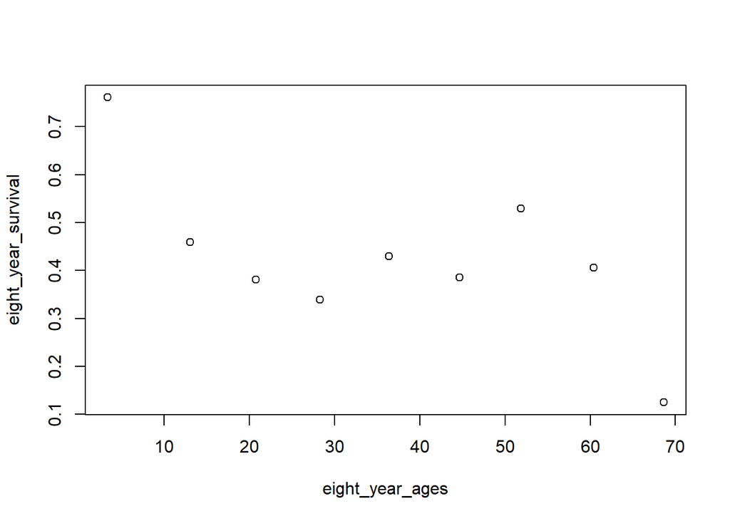

```r
plot(eight_year_ages, eight_year_survival)
```

You can do a formal fit using smoothing splines.

```r
library(gam)
```

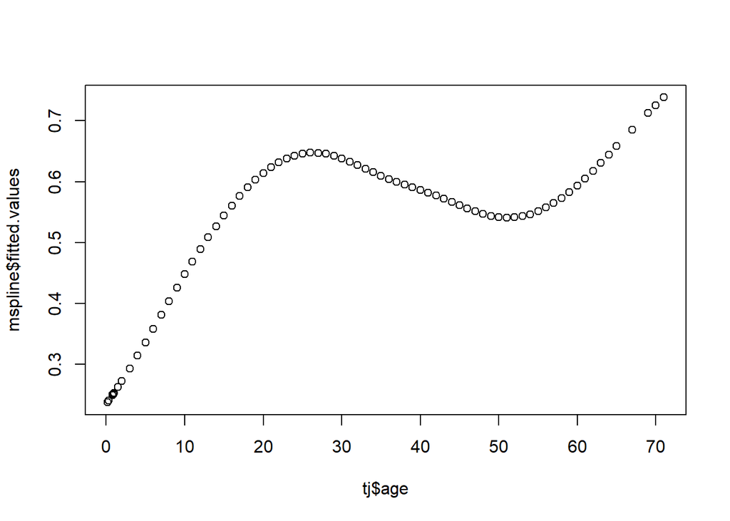

```r
mspline <- gam(ideath~s(age, df=4), family=binomial, data=tj)
plot(tj$age, mspline$fitted.values)
```

Now let’s look at a more complex logistic regression model with two factors, sex and passenger class. If you saw the movie, Leonardo and his third class compatriots were locked down until all the first class passengers boarded the life boats. That’s not good news on a rapidly sinking ship.

You should look at passenger class by itself before thinking about how it might interact with sex.

```r
prop.table(table(ti$pclass, ti$status), margin=1)
```

```
##
##            died     lived
##   1st 0.4006211 0.5993789
##   2nd 0.5750000 0.4250000
##   3rd 0.8059072 0.1940928
```

```r
oddsratio(ti$pclass, ti$status)
```

```
## $data
##          Outcome
## Predictor died lived Total
##     1st    129   193   322
##     2nd    161   119   280
##     3rd    573   138   711
##     Total  863   450  1313
##
## $measure
##          odds ratio with 95% C.I.
## Predictor  estimate     lower     upper
##       1st 1.0000000        NA        NA
##       2nd 0.4948165 0.3566409 0.6844171
##       3rd 0.1614237 0.1204184 0.2153400
##
## $p.value
##          two-sided
## Predictor   midp.exact fisher.exact   chi.square
##       1st           NA           NA           NA
##       2nd 1.989474e-05 2.103202e-05 1.946566e-05
##       3rd 0.000000e+00 4.887415e-37 3.055894e-38
##
## $correction
## [1] FALSE
##
## attr(,"method")
## [1] "median-unbiased estimate & mid-p exact CI"
```

```r
mclass <- glm(survived~pclass, family=binomial, data=ti)
tclass <- tidy(mclass)
tclass$lcl <- round(exp(tclass$estimate-1.96*tclass$std.error), 2)
tclass$ucl <- round(exp(tclass$estimate+1.96*tclass$std.error), 2)
tclass$estimate <- round(exp(tclass$estimate), 2)
tclass[, c("term", "estimate", "lcl", "ucl")]
```

```
##          term estimate  lcl  ucl
## 1 (Intercept)     1.50 1.20 1.87
## 2   pclass2nd     0.49 0.36 0.68
## 3   pclass3rd     0.16 0.12 0.22
```

```r
n <- data.frame(pclass=sort(unique(ti$pclass)))
print(n)
```

```
##   pclass
## 1    1st
## 2    2nd
## 3    3rd
```

```r
augment(mclass, newdata=n, type.predict="response")
```

```
##   pclass   .fitted    .se.fit
## 1    1st 0.5993789 0.02730799
## 2    2nd 0.4250000 0.02954264
## 3    3rd 0.1940928 0.01483243
```

An interaction means that the effect of one independent variable is not the same across the levels of the other independent variable. In the Titanic example, an interaction between sex and passenger class means that the protection afforded to women by a “women and children first” policy is not the same across each passsenger class.

```r
oddsratio(ti$sex[ti$pclass=="1st"], ti$status[ti$pclass=="1st"], rev="rows")
```

```
## $data
##          Outcome
## Predictor died lived Total
##    male    120    59   179
##    female    9   134   143
##    Total   129   193   322
##
## $measure
##          odds ratio with 95% C.I.
## Predictor estimate    lower    upper
##    male    1.00000       NA       NA
##    female 29.48543 14.69098 66.57353
##
## $p.value
##          two-sided
## Predictor midp.exact fisher.exact   chi.square
##    male           NA           NA           NA
##    female          0 1.086515e-31 2.130831e-28
##
## $correction
## [1] FALSE
##
## attr(,"method")
## [1] "median-unbiased estimate & mid-p exact CI"
```

```r
oddsratio(ti$sex[ti$pclass=="2nd"], ti$status[ti$pclass=="2nd"], rev="rows")
```

```
## $data
##          Outcome
## Predictor died lived Total
##    male    148    25   173
##    female   13    94   107
##    Total   161   119   280
##
## $measure
##          odds ratio with 95% C.I.
## Predictor estimate    lower   upper
##    male    1.00000       NA      NA
##    female 41.49306 20.85644 88.8078
##
## $p.value
##          two-sided
## Predictor midp.exact fisher.exact   chi.square
##    male           NA           NA           NA
##    female          0 5.079791e-36 1.473814e-33
##
## $correction
## [1] FALSE
##
## attr(,"method")
## [1] "median-unbiased estimate & mid-p exact CI"
```

```r
oddsratio(ti$sex[ti$pclass=="3rd"], ti$status[ti$pclass=="3rd"], rev="rows")
```

```
## $data
##          Outcome
## Predictor died lived Total
##    male    441    58   499
##    female  132    80   212
##    Total   573   138   711
##
## $measure
##          odds ratio with 95% C.I.
## Predictor estimate    lower    upper
##    male   1.000000       NA       NA
##    female 4.592543 3.115376 6.811806
##
## $p.value
##          two-sided
## Predictor   midp.exact fisher.exact   chi.square
##    male             NA           NA           NA
##    female 1.110223e-14 1.184368e-14 8.043934e-16
##
## $correction
## [1] FALSE
##
## attr(,"method")
## [1] "median-unbiased estimate & mid-p exact CI"
```

You can see the sex effect is in the double digits for first and second class, but much smaller in third class.

```r
mint <- glm(survived~pclass*sex, family=binomial, data=ti)
tint <- tidy(mint)
print(tint)
```

```
##                term   estimate std.error  statistic      p.value
## 1       (Intercept)  2.7006152 0.3443434  7.8427973 4.406190e-15
## 2         pclass2nd -0.7222698 0.4540195 -1.5908342 1.116469e-01
## 3         pclass3rd -3.2013905 0.3723548 -8.5976878 8.133818e-18
## 4           sexmale -3.4105695 0.3792820 -8.9921733 2.423892e-19
## 5 pclass2nd:sexmale -0.3461124 0.5274211 -0.6562354 5.116727e-01
## 6 pclass3rd:sexmale  1.8827429 0.4282984  4.3958670 1.103315e-05
```

```r
tint$lcl <- round(exp(tint$estimate-1.96*tint$std.error), 2)
tint$ucl <- round(exp(tint$estimate+1.96*tint$std.error), 2)
tint$estimate <- round(exp(tint$estimate), 2)
tint[, c("term", "estimate", "lcl", "ucl")]
```

```
##                term estimate  lcl   ucl
## 1       (Intercept)    14.89 7.58 29.24
## 2         pclass2nd     0.49 0.20  1.18
## 3         pclass3rd     0.04 0.02  0.08
## 4           sexmale     0.03 0.02  0.07
## 5 pclass2nd:sexmale     0.71 0.25  1.99
## 6 pclass3rd:sexmale     6.57 2.84 15.21
```

```r
n1 <- sort(unique(ti$sex))
n2 <- sort(unique(ti$pclass))
n <- data.frame(sex=rep(n1, length(n2)), pclass=rep(n2, each=length(n1)))
print(n)
```

```
##      sex pclass
## 1 female    1st
## 2   male    1st
## 3 female    2nd
## 4   male    2nd
## 5 female    3rd
## 6   male    3rd
```

```r
augment(mint, newdata=n, type.predict="response")
```

```
##      sex pclass   .fitted    .se.fit
## 1 female    1st 0.9370629 0.02030799
## 2   male    1st 0.3296089 0.03513477
## 3 female    2nd 0.8785047 0.03158348
## 4   male    2nd 0.1445087 0.02673202
## 5 female    3rd 0.3773585 0.03329110
## 6   male    3rd 0.1162325 0.01434771
```

Save everything for possible later use.

```r
save.image("logistic-regression.RData")
```